# Beta-distribution phenotype-SD estimation

How far a uniform common-variant MAF shortcut gets for EUR-like and AFR-like GWAS

Published

July 15, 2026

```r
library(dplyr)
library(ggplot2)
library(knitr)
library(scales)
library(tibble)
library(tidyr)

set.seed(20260715)

true_trait_sd <- 1.7
n_gwas <- 50000
maf_min <- 0.05
maf_max <- 0.5
sample_sizes <- c(1000, 10000, 50000)
n_reps <- 200

k_of_maf <- function(maf) 1 / (2 * maf * (1 - maf))

sample_common_maf <- function(n, profile) {
  out <- numeric(0)
  while (length(out) < n) {
    m <- max(n * 3, 10000)
    if (profile == "EUR-like") {
      # A toy common-variant distribution: more mass near the lower common-MAF
      # boundary than a uniform distribution.
      q <- ifelse(runif(m) < 0.7, rbeta(m, 0.75, 1.55), runif(m))
    } else if (profile == "AFR-like") {
      # A toy common-variant distribution closer to flat, with a little extra
      # intermediate-frequency mass.
      q <- ifelse(runif(m) < 0.55, rbeta(m, 1.15, 1.15), runif(m))
    } else {
      q <- runif(m)
    }
    maf <- pmin(q, 1 - q)
    maf <- maf[maf >= maf_min & maf <= maf_max]
    out <- c(out, maf)
  }
  out[seq_len(n)]
}

reference_k <- tibble(profile = c("EUR-like", "AFR-like", "Uniform common MAF")) |>
  mutate(
    maf = lapply(profile, \(p) {
      if (p == "Uniform common MAF") runif(500000, maf_min, maf_max)
      else sample_common_maf(500000, p)
    }),
    expected_k = vapply(maf, \(x) mean(k_of_maf(x)), numeric(1))
  ) |>
  select(profile, expected_k)

uniform_expected_k <- reference_k |>
  filter(profile == "Uniform common MAF") |>
  pull(expected_k)

simulate_one <- function(profile, n_variants) {
  maf <- sample_common_maf(n_variants, profile)
  se <- true_trait_sd / sqrt(n_gwas / k_of_maf(maf))
  beta <- rnorm(n_variants, mean = 0, sd = se)
  beta_sd <- sd(beta)
  profile_expected_k <- reference_k |>
    filter(profile == !!profile) |>
    pull(expected_k)

  tibble(
    method = c("oracle sample MAF", "profile reference MAF", "uniform common MAF"),
    estimated_trait_sd = c(
      beta_sd * sqrt(n_gwas / mean(k_of_maf(maf))),
      beta_sd * sqrt(n_gwas / profile_expected_k),
      beta_sd * sqrt(n_gwas / uniform_expected_k)
    )
  )
}

sim <- expand_grid(
  profile = c("EUR-like", "AFR-like"),
  n_variants = sample_sizes,
  rep = seq_len(n_reps)
) |>
  rowwise() |>
  do(bind_cols(
    tibble(profile = .$profile, n_variants = .$n_variants, rep = .$rep),
    simulate_one(.$profile, .$n_variants)
  )) |>
  ungroup() |>
  mutate(
    relative_error = estimated_trait_sd / true_trait_sd - 1,
    abs_relative_error = abs(relative_error),
    method = factor(method, c("oracle sample MAF", "profile reference MAF", "uniform common MAF"))
  )
```

## Purpose

This is a quick toy calculation for the effect-scale ticket. It asks whether a random sample of common-variant betas can recover a continuous trait’s phenotype SD when `N` is known but variant-level MAF is missing.

For null common variants,

```
SE(beta) ~= trait_sd / sqrt(2 * N * MAF * (1 - MAF))
```

If we only observe the spread of betas, then:

```
sd(beta) ~= trait_sd * sqrt(E[1 / (2 * MAF * (1 - MAF))] / N)
```

So the shortcut is only as good as the assumed MAF distribution and the assumption that the sampled variants are mostly null. Here we simulate two toy common-variant profiles:

- `EUR-like`: common variants are skewed toward lower MAF.
- `AFR-like`: common variants are closer to uniform across 0.05-0.5.

This is not a real reference-panel benchmark. It is a cheap sanity check for whether the shortcut belongs at the bottom of the provenance ladder.

## Expected MAF factor

The estimator hinges on `E[1 / (2 * MAF * (1 - MAF))]`. Uniform common MAF is a decent but not neutral assumption: lower-MAF enrichment increases this factor, which changes the inferred phenotype SD.

```r
kable(
  reference_k |>
    mutate(expected_k = round(expected_k, 3)),
  col.names = c("Assumed MAF profile", "E[1 / (2p(1-p))]"),
  caption = "MAF-distribution factor used to turn sd(beta) into phenotype SD."
)
```

MAF-distribution factor used to turn sd(beta) into phenotype SD.

| Assumed MAF profile | E[1 / (2p(1-p))] |
| --- | --- |
| EUR-like | 3.378 |
| AFR-like | 3.219 |
| Uniform common MAF | 3.274 |

## Accuracy by sample size

```r
summary_tbl <- sim |>
  group_by(profile, n_variants, method) |>
  summarise(
    median_error_pct = 100 * median(relative_error),
    p05_error_pct = 100 * quantile(relative_error, 0.05),
    p95_error_pct = 100 * quantile(relative_error, 0.95),
    within_10_pct = mean(abs_relative_error <= 0.10),
    .groups = "drop"
  )

kable(
  summary_tbl |>
    mutate(across(ends_with("_pct"), \(x) round(x, 1)),
           within_10_pct = percent(within_10_pct, accuracy = 1)),
  col.names = c("Profile", "Betas sampled", "Method", "Median error (%)",
                "5th pct error (%)", "95th pct error (%)", "Within 10%"),
  caption = "Relative error in phenotype-SD estimates over simulated GWAS replicates."
)
```

Relative error in phenotype-SD estimates over simulated GWAS replicates.

| Profile | Betas sampled | Method | Median error (%) | 5th pct error (%) | 95th pct error (%) | Within 10% |
| --- | --- | --- | --- | --- | --- | --- |
| AFR-like | 1000 | oracle sample MAF | 0.5 | -4.5 | 4.2 | 100% |
| AFR-like | 1000 | profile reference MAF | 0.5 | -4.6 | 4.9 | 100% |
| AFR-like | 1000 | uniform common MAF | -0.4 | -5.4 | 4.0 | 100% |
| AFR-like | 10000 | oracle sample MAF | 0.0 | -1.4 | 1.2 | 100% |
| AFR-like | 10000 | profile reference MAF | 0.0 | -1.5 | 1.2 | 100% |
| AFR-like | 10000 | uniform common MAF | -0.8 | -2.3 | 0.3 | 100% |
| AFR-like | 50000 | oracle sample MAF | 0.0 | -0.6 | 0.6 | 100% |
| AFR-like | 50000 | profile reference MAF | -0.1 | -0.7 | 0.6 | 100% |
| AFR-like | 50000 | uniform common MAF | -0.9 | -1.5 | -0.3 | 100% |
| EUR-like | 1000 | oracle sample MAF | -0.1 | -4.1 | 4.5 | 100% |
| EUR-like | 1000 | profile reference MAF | 0.0 | -3.8 | 4.9 | 100% |
| EUR-like | 1000 | uniform common MAF | 1.5 | -2.3 | 6.5 | 100% |
| EUR-like | 10000 | oracle sample MAF | -0.1 | -1.3 | 1.3 | 100% |
| EUR-like | 10000 | profile reference MAF | -0.1 | -1.4 | 1.4 | 100% |
| EUR-like | 10000 | uniform common MAF | 1.4 | 0.1 | 3.0 | 100% |
| EUR-like | 50000 | oracle sample MAF | 0.0 | -0.7 | 0.5 | 100% |
| EUR-like | 50000 | profile reference MAF | -0.1 | -0.8 | 0.5 | 100% |
| EUR-like | 50000 | uniform common MAF | 1.5 | 0.8 | 2.0 | 100% |

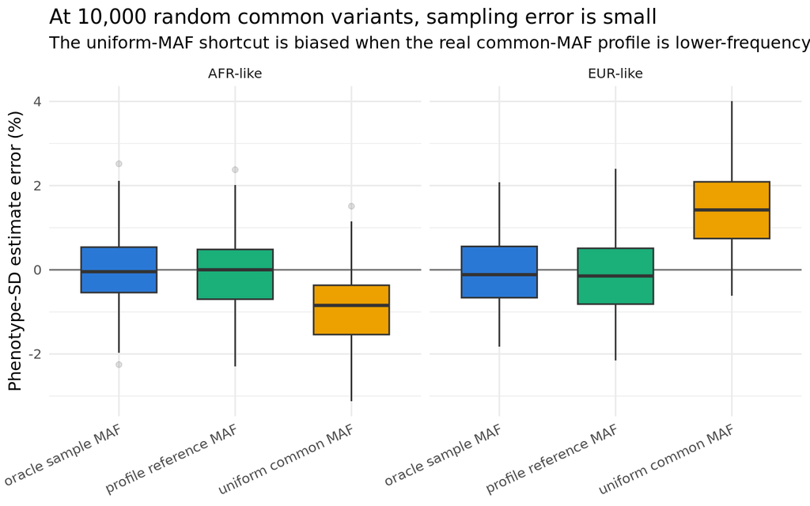

```r
plot_dat <- sim |>
  filter(n_variants == 10000)

ggplot(plot_dat, aes(method, 100 * relative_error, fill = method)) +
  geom_hline(yintercept = 0, colour = "grey45") +
  geom_boxplot(width = 0.65, outlier.alpha = 0.15) +
  facet_wrap(~profile) +
  scale_fill_manual(values = c(
    "oracle sample MAF" = "#2a78d6",
    "profile reference MAF" = "#1baf7a",
    "uniform common MAF" = "#eda100"
  )) +
  labs(x = NULL, y = "Phenotype-SD estimate error (%)",
       title = "At 10,000 random common variants, sampling error is small",
       subtitle = "The uniform-MAF shortcut is biased when the real common-MAF profile is lower-frequency enriched.") +
  theme_minimal(base_size = 12) +
  theme(legend.position = "none",
        axis.text.x = element_text(angle = 25, hjust = 1))
```

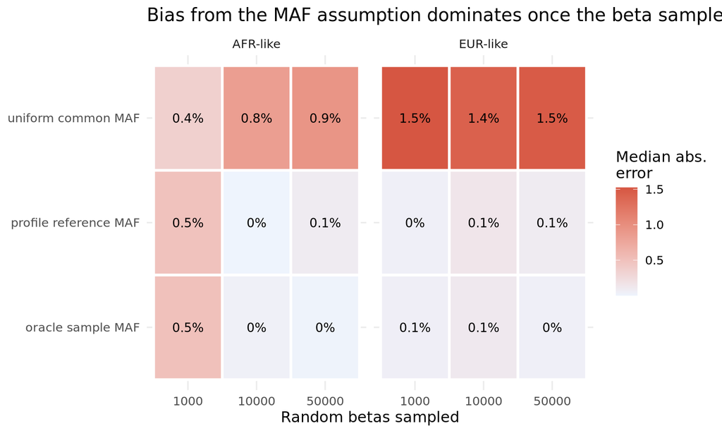

```r
heat <- summary_tbl |>
  mutate(median_abs_error_pct = abs(median_error_pct))

ggplot(heat, aes(factor(n_variants), method, fill = median_abs_error_pct)) +
  geom_tile(colour = "white", linewidth = 1) +
  geom_text(aes(label = paste0(round(median_abs_error_pct, 1), "%")), size = 3.5) +
  facet_wrap(~profile) +
  scale_fill_gradient(low = "#eef4fd", high = "#d65642", name = "Median abs.\nerror") +
  labs(x = "Random betas sampled", y = NULL,
       title = "Bias from the MAF assumption dominates once the beta sample is large") +
  theme_minimal(base_size = 12)
```

## Takeaways

The beta-distribution shortcut is plausible as a low-effort fallback, but it is not in the same class as `SE + source MAF` or `SE + reference MAF`.

For the effect-scale provenance ladder:

- `estimated_from_beta_distribution` should sit below reference-MAF estimation.
- It should be restricted to common-variant random samples, not top hits.
- It should record the assumed MAF profile, `N`, number of sampled betas, MAF bounds, excluded variants, and the estimator version.
- It is useful as a triage/QC signal even when it is too assumption-heavy to rescale a published store automatically.

The shortcut looks most defensible when the sample contains thousands of random common variants and the real common-MAF profile is close to the assumed profile. It becomes fragile when the source has strong MAF-dependent filtering, enriched low-frequency variants, winner’s-curse/top-hit sampling, or mixed ancestry.